# Machine Learning Project

This project is to anaylize data and predict behavior from accelerometers on the belt, forearm, arm, and dumbell of 6 participants, who were asked to perform barbell lifts correctly and incorrectly in 5 different ways. The outcome of the pridicting variable is the “classe” variable in the training set. In this analysis, the data will be explored and cleaned, the outcome will then be predicted with a selected model, the model will be tested with accuracy on predicting the test set.

## Collect and clean data

The data is first read into the pmldata dataset.

```r
pmldata = read.csv("Downloads/pml-training.csv")  # read csv file
head(pmldata)

pmltesting = read.csv("Downloads/pml-testing.csv")  # read csv file
head(pmltesting)
```

After viewing the data, it was found that significant portion of the columns are filled with nonavailable contents or contents with zeros. Futhermore, in the testing dataset, many of the same columns are all filled with nonavaialbe values. It leads to the decision to extract the following variables to predict the outcome: user_name, roll_belt, pitch_belt, yaw_belt, total_accel_belt, roll_arm, pitch_arm, yaw_arm, total_accel_arm, roll_dumbbell,pitch_dumbbell, yaw_dumbbell, total_accel_dumbbell, roll_forearm, pitch_forearm, yaw_forearm, total_accel_forearm

These columns could be extracted simply by a line of script:

```r
pmlData<-pmldata[ , grepl("user_name|^roll_|^pitch_|^yaw_|^total_accel_|classe", names(pmldata))]
#cleaning the data so that only complete cases are present
pmlData<-pmlData[complete.cases(pmlData),]
head(pmlData)
```

```r
dim(pmlData)
```

[1] 19622 18

## Expectation of Out of Sample Errors

Because of both signal and noise presents in the traning set, out of expect error generally occurs when building the training model from the training set and applies it to the test set. The approach to more accurate prediction is to eliminate the noises of the training set. Fortunately, we have a large dataset. In this case, the whole data will be randomly splited into a training and a testing set, where the testing set is to evaluate the final prediciton.

```r
# load packages and data
library(caret)
set.seed(12345)

inTraining <- createDataPartition(pmlData$classe, p = .75, list = FALSE)
training <- pmlData[ inTraining,]
testing  <- pmlData[-inTraining,]
```

## Cross Validation

To the training set, the data will be splited into 10 folds. We are able to fit/test a model with different parameters to the find the best ones on the cross-validated test sets. In this case, the model will be built and optimized using the 10-fold cross validation and twice sampling.

```r
fitControl <- trainControl(## 10-fold CV
                           method = "repeatedcv",
                           number = 10,
                           ## repeated 2 times
                           repeats = 2)
```

## Build Prediciton Moedel

We use Gradient Boosting machine (GBM) model to predict the outcome. It produces a prediction model in the form of an ensemble of weak prediction models, typically decision trees. It builds the model in a stage-wise fashion like other boosting methods do, and it generalizes them by allowing optimization of an arbitrary differentiable loss function.

```r
set.seed(825)
gbmFit1 <- train(classe ~ ., as.data.frame(training),
                 method = "gbm",
                 trControl = fitControl,
                 ## This last option is actually one
                 ## for gbm() that passes through
                 verbose = FALSE
                 )
gbmFit1
```

```
## Stochastic Gradient Boosting
##
## 14718 samples
##    17 predictor
##     5 classes: 'A', 'B', 'C', 'D', 'E'
##
## No pre-processing
## Resampling: Cross-Validated (10 fold, repeated 2 times)
## Summary of sample sizes: 13247, 13246, 13246, 13247, 13245, 13248, ...
## Resampling results across tuning parameters:
##
##   interaction.depth  n.trees  Accuracy   Kappa      Accuracy SD
##   1                   50      0.6957455  0.6144868  0.012380017
##   1                  100      0.7490140  0.6827119  0.011688631
##   1                  150      0.7790787  0.7207294  0.012003945
##   2                   50      0.8069018  0.7560110  0.013345228
##   2                  100      0.8728765  0.8393164  0.011202709
##   2                  150      0.9017538  0.8757829  0.007698598
##   3                   50      0.8660821  0.8306864  0.011365509
##   3                  100      0.9176871  0.8959199  0.008638147
##   3                  150      0.9392246  0.9231461  0.007857178
##   Kappa SD
##   0.016036957
##   0.014874121
##   0.015267743
##   0.016807261
##   0.014193167
##   0.009765096
##   0.014394190
##   0.010936054
##   0.009938687
##
## Tuning parameter 'shrinkage' was held constant at a value of 0.1
##
## Tuning parameter 'n.minobsinnode' was held constant at a value of 10
## Accuracy was used to select the optimal model using  the largest value.
## The final values used for the model were n.trees = 150,
##  interaction.depth = 3, shrinkage = 0.1 and n.minobsinnode = 10.
```

# Evaluating the Prediction Model

The original test set remains completely untouched at this stage, so when final prediction algorithm is applied, the result will only be an unbiased measurement of the of sample accuracy of the model. We can furhter analyze the accuracy of the prediction of the model using the testing set.

To Statistically analyze the prediction, we can use a confusionMatrix:

```r
# result evaluation
confusionMatrix(testing$classe,predict(gbmFit1,testing))
```

```
## Confusion Matrix and Statistics
##
##           Reference
## Prediction    A    B    C    D    E
##          A 1357   19    8    8    3
##          B   42  840   56    7    4
##          C    0   30  802   21    2
##          D    5    8   21  759   11
##          E    8   14   13   16  850
##
## Overall Statistics
##
##                Accuracy : 0.9396
##                  95% CI : (0.9326, 0.9461)
##     No Information Rate : 0.2879
##     P-Value [Acc > NIR] : < 2.2e-16
##
##                   Kappa : 0.9236
##  Mcnemar's Test P-Value : 7.161e-06
##
## Statistics by Class:
##
##                      Class: A Class: B Class: C Class: D Class: E
## Sensitivity            0.9610   0.9221   0.8911   0.9359   0.9770
## Specificity            0.9891   0.9727   0.9868   0.9890   0.9874
## Pos Pred Value         0.9728   0.8851   0.9380   0.9440   0.9434
## Neg Pred Value         0.9843   0.9820   0.9758   0.9873   0.9950
## Prevalence             0.2879   0.1858   0.1835   0.1654   0.1774
## Detection Rate         0.2767   0.1713   0.1635   0.1548   0.1733
## Detection Prevalence   0.2845   0.1935   0.1743   0.1639   0.1837
## Balanced Accuracy      0.9751   0.9474   0.9389   0.9624   0.9822
```

If We want to see how the prediction re-iterate itself, we can do a plot with on it.

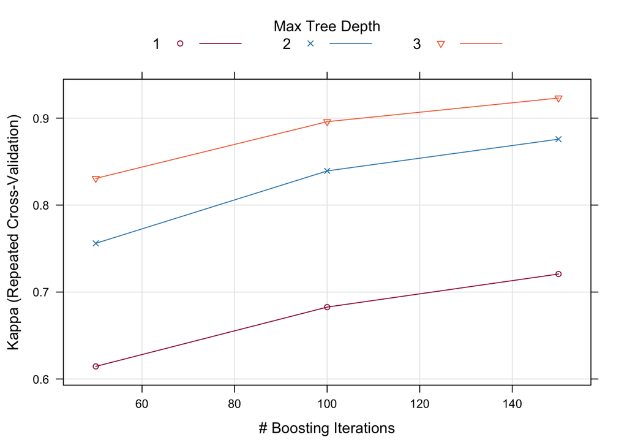

```r
# plot
trellis.par.set(caretTheme())
plot(gbmFit1, metric = "Kappa")
```

At the end, we can also find the most impacted variables in the prediction.

```r
varImp(gbmFit1)
```

```
## gbm variable importance
##
##   only 20 most important variables shown (out of 21)
##
##                      Overall
## roll_belt            100.000
## pitch_forearm         58.346
## yaw_belt              46.362
## roll_forearm          29.847
## pitch_belt            29.204
## roll_dumbbell         21.717
## total_accel_dumbbell  21.230
## yaw_dumbbell          12.009
## user_nameeurico       11.152
## yaw_arm                8.557
## pitch_dumbbell         7.312
## total_accel_forearm    6.791
## total_accel_belt       6.141
## roll_arm               5.627
## yaw_forearm            2.223
## total_accel_arm        1.854
## pitch_arm              1.398
## user_namejeremy        0.000
## user_namecharles       0.000
## user_namepedro         0.000
```